# Line Graphs with R and SPSS

R

Graphs

Descriptive Stats

Creating line graphs with R and SPSS

Ovande Furtado https://drfurtado.netlify.app (Cal State Northridge)https://csun.edu  
12-29-2020

# Introduction

*R* and RStudio are two great tools for creating graphs. Although I think SPSS scores high on the graph creation category, it has several limitations. Arguably, its main shortcoming has to do with the lack of flexibility. This is not the case with *R* and RStudio.

Below, I will show how to create beautiful graphs with *R* and RStudio.

I will get started with line graphs.

You may skip to the last step if you want to create the Multiple lines graph (with legends).

## Single line graph with *R*

To follow along, open RStudio, then create a new *R* script[^1]. Then, copy and paste each chunk of code into the newly created script.

Finally, run *separately* each step (chunk of code) to create a Single line graph. We will start with Step 1, then run Step 2 to create the graph shown in Figure 1. Notice that this graph does not have the lines (or titles), yet.

### Step 1

```
# Step 1: Create two variables (x, y) and assign numbers to each
x <- c(1:5)
y <- c(12,18,22,20,28)
```

### Step 2

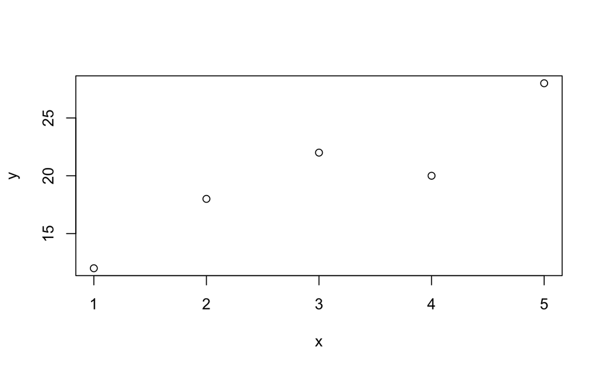

Figure 1: Single

```
# Step 2: Create a Single plot
plot(x, y)
```

### Step 3

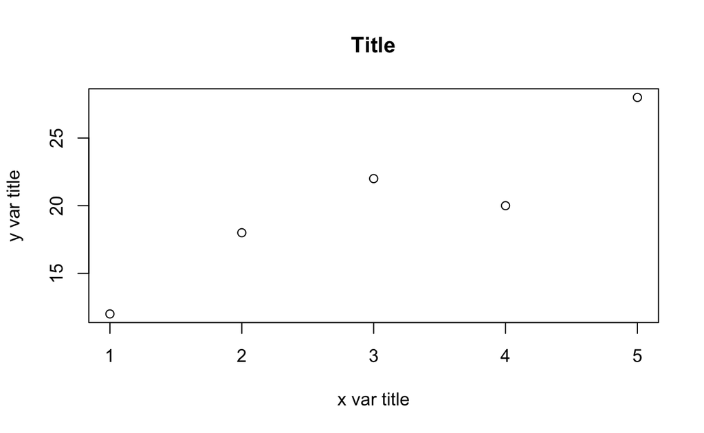

Figure 2: Single

```
# Step 3: Let's add labels for x and y and a title for the plot
plot(x, y, xlab = "x var title", ylab = "y var title", main = "Title")
```

### Step 4

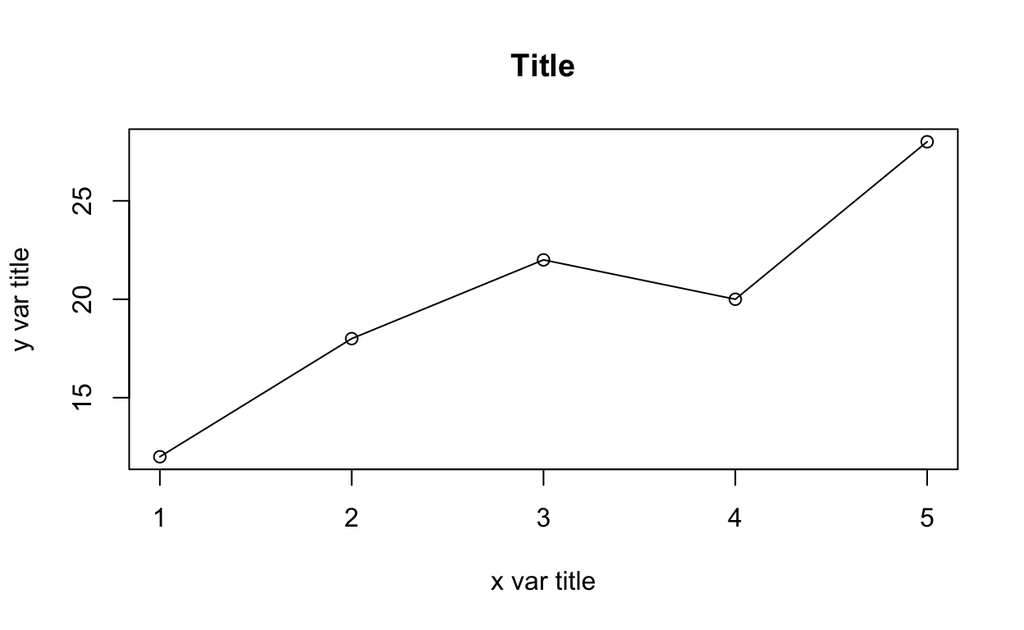

Figure 3: Single

```
# Step 4: Let's draw a line
plot(x, y, xlab = "x var title", ylab = "y var title", main = "Title",
     type = "o")
```

### Step 5

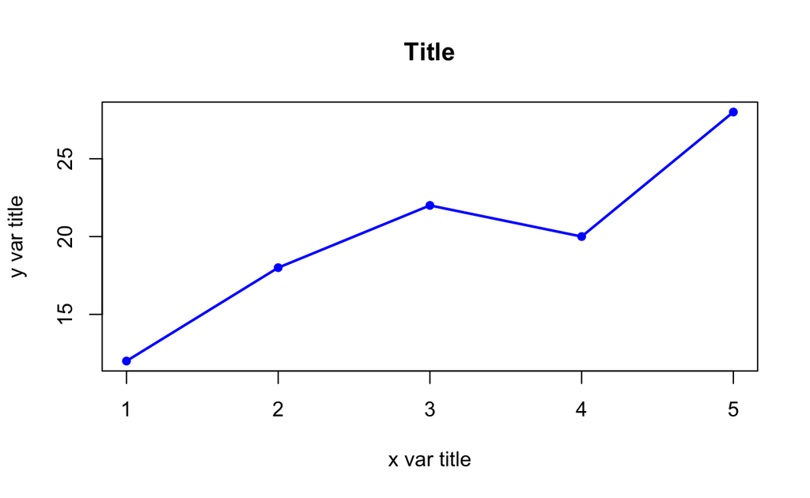

Figure 4: Single graph line with titles

```
# Step 5: Let's change the density and color of the line and dots
plot(x, y, xlab = "x var title", ylab = "y var title", main = "Title",
     type = "o", pch = 20, lwd = 2, col = "blue")
```

## Multiple lines graph with *R*

The R script for this section was adapted from: http://bit.ly/34fDitr

**What you need to know**

Three groups were tested 5 times (once every week for a period of 5 weeks) on BMI (body mass index). For a period of five weeks, two groups engaged in a physical fitness program whereas G1 did not exercise at all. Using this information, plot BMI changes over time for the three groups.

```
Group 1 (G1) = No exercise (control group)
Group 2 (G2) = Traditional fitness program
Group 3 (G3) = New fitness program
```

### Step 1

```
# define 3 data sets
time <- c(1,2,3,4,5) # or simply c(1:5)
y1 <- c(24,24,26,23,25)      # Group 1
y2 <- c(28, 25, 26, 25, 24)  # Group 2
y3 <- c(30,30, 28, 26, 25)   # Group 3
```

### Step 2

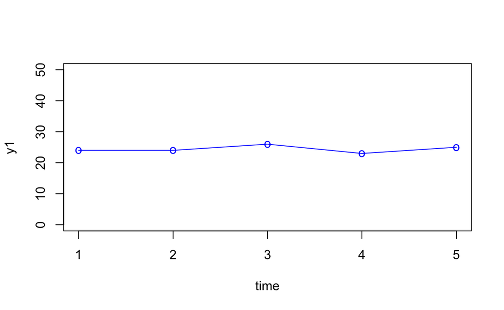

Figure 5: Multi

```
# plot the first curve by calling plot() function
# First curve is plotted
plot(time, y1, type="o", col="blue", pch="o", lty=1, ylim=c(0,50))
```

### Step 3

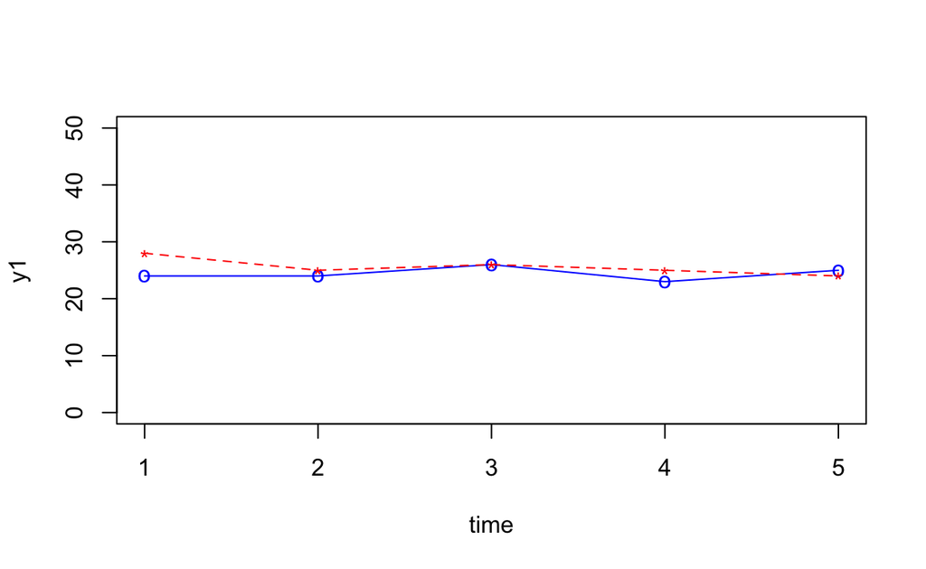

Figure 6: Multi

```
# Add second curve to the same plot by calling points() and lines()
# Use symbol '*' for points.
plot(time, y1, type="o", col="blue", pch="o", lty=1, ylim=c(0,50))
points(time, y2, col="red", pch='*')
lines(time, y2, col="red",lty=2)
```

### Step 4

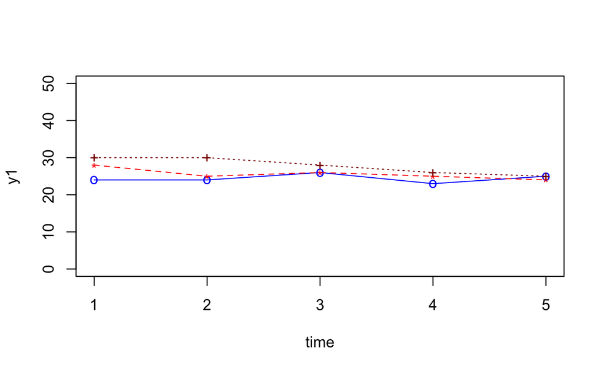

Figure 7: Multi

```
# Add Third curve to the same plot by calling points() and lines()
# Use symbol '+' for points.
plot(time, y1, type="o", col="blue", pch="o", lty=1, ylim=c(0,50))
points(time, y2, col="red", pch='*')
lines(time, y2, col="red",lty=2)
points(time, y3, col="dark red",pch="+")
lines(time, y3, col="dark red", lty=3)
```

After running the script above, you will notice an empty space on the top-half of the plot. So, change the following: (1) Change the `ylim` argument to `20`, `35`. This will improve the look of the plot. (2) In addition, add `labels` to `y` and `x` and a `main title` to the plot. Refer to Figure 2 for more details.

### Step 5

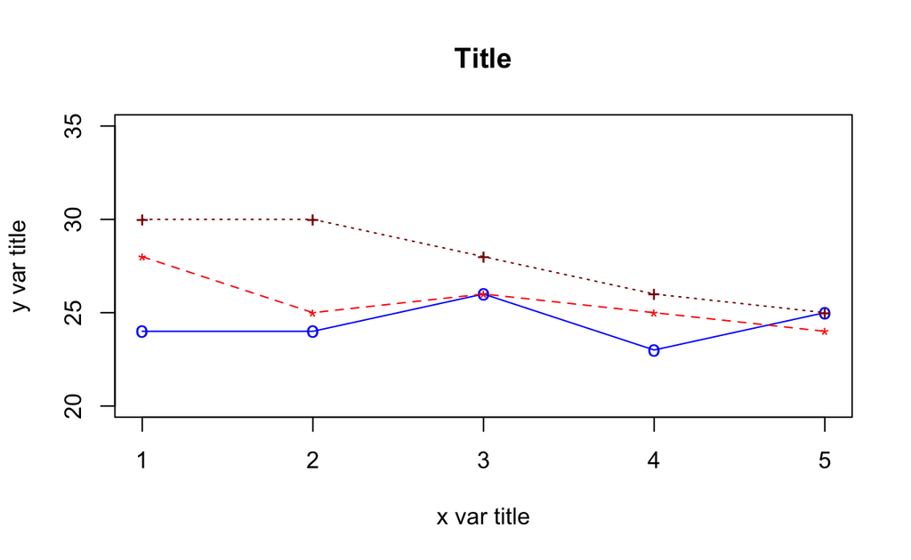

Figure 8: Multi

```
# Add Third curve to the same plot by calling points() and lines()
# Use symbol '+' for points.
plot(time, y1, xlab = "x var title", ylab = "y var title", main = "Title", type="o", col="blue", pch="o", lty=1, ylim=c(20,35))
points(time, y2, col="red", pch='*')
lines(time, y2, col="red",lty=2)
points(time, y3, col="dark red",pch="+")
lines(time, y3, col="dark red", lty=3)
```

## Multiple lines graph (with legends) with *R*

Below is the R script to create a plot with multiple lines and a legend. To do this, create a new script, then paste the script below into RStudio and run the script the same way it was done previously.

### Step 1

```
# define 3 data sets
xtime <- c(1,2,3,4,5) # or simply c(1:5)
y1 <- c(24,24,26,23,25)     # Group 1
y2 <- c(28,25,26,25,24)     # Group 2
y3 <- c(30,30,28,26,25)     # Group 3
```

### Step 2

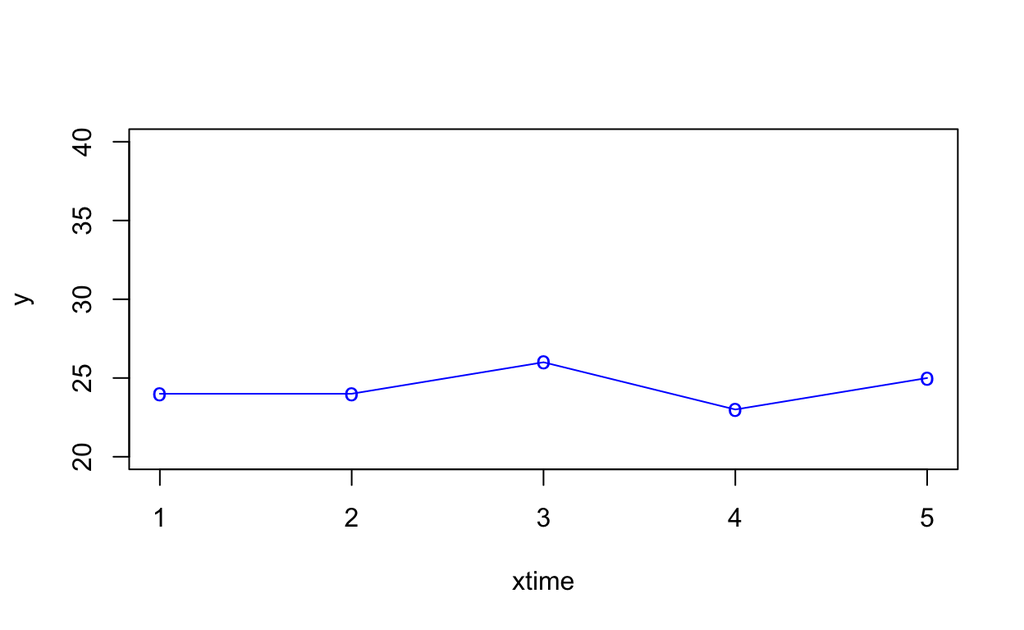

```
# plot the first curve by calling plot() function
# First curve is plotted
plot(xtime, y1, type="o", col="blue", pch="o", lty=1, ylim=c(20,40), ylab="y" )
```

### Step 3

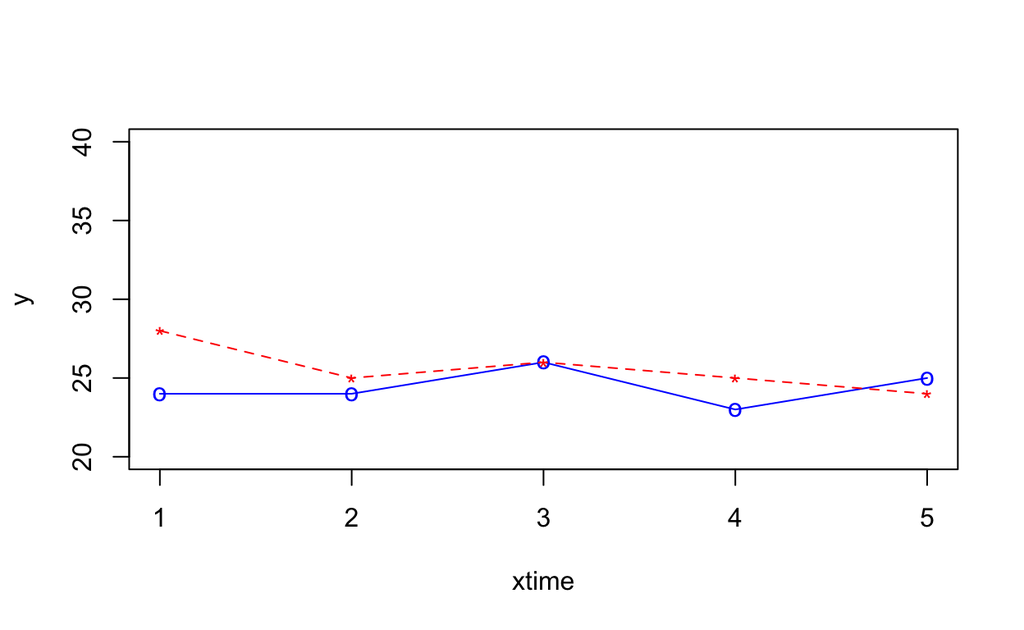

```
# Add second curve to the same plot by calling points() and lines()
# Use symbol '*' for points.
plot(xtime, y1, type="o", col="blue", pch="o", lty=1, ylim=c(20,40), ylab="y" )
points(xtime, y2, col="red", pch="*")
lines(xtime, y2, col="red",lty=2)
```

### Step 4

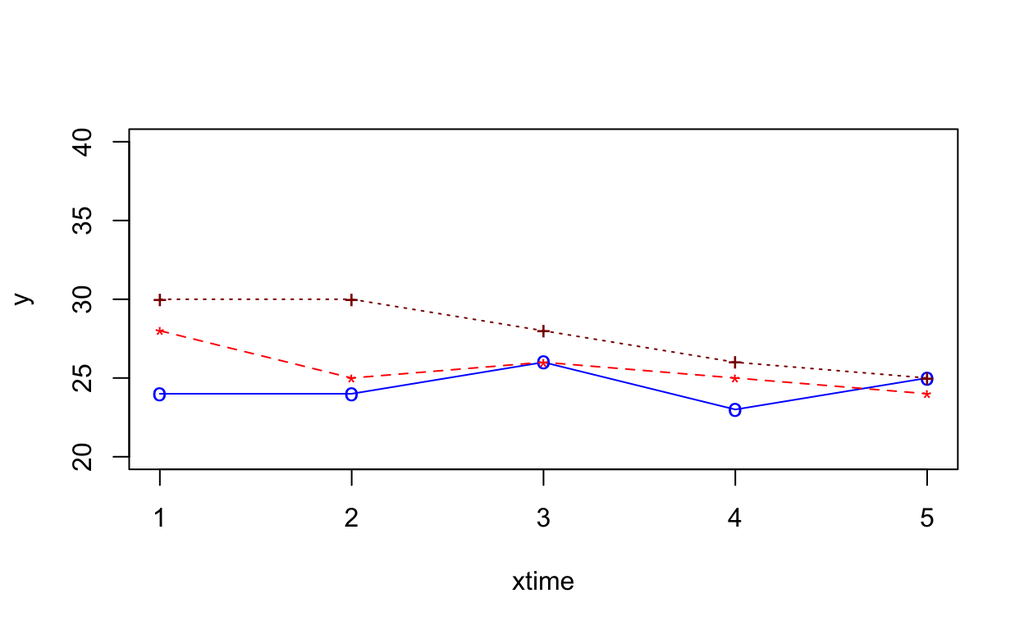

```
# Add Third curve to the same plot by calling points() and lines()
# Use the symbol '+' for points.
plot(xtime, y1, type="o", col="blue", pch="o", lty=1, ylim=c(20,40), ylab="y" )
points(xtime, y2, col="red", pch="*")
lines(xtime, y2, col="red",lty=2)
points(xtime, y3, col="dark red",pch="+")
lines(xtime, y3, col="dark red", lty=3)
```

### Step 5

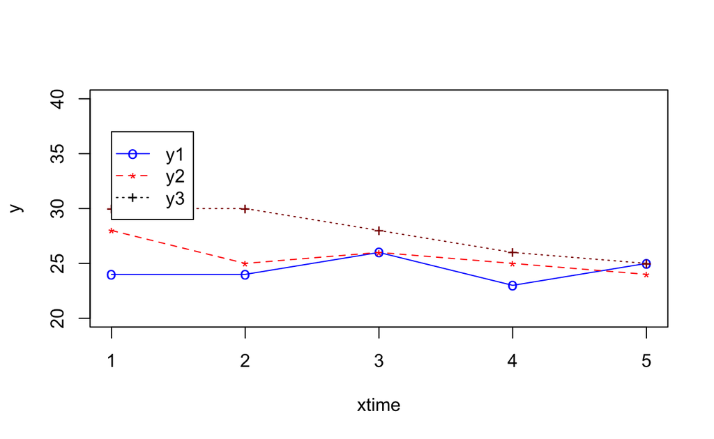

```
# Adding a legend inside the box at the location (1,37) in graph coordinates.
# Note that the order of plots are maintained in the vectors of attributes.
plot(xtime, y1, type="o", col="blue", pch="o", lty=1, ylim=c(20,40), ylab="y" )
points(xtime, y2, col="red", pch="*")
lines(xtime, y2, col="red",lty=2)
points(xtime, y3, col="dark red",pch="+")
lines(xtime, y3, col="dark red", lty=3)
legend(1,37,legend=c("y1","y2","y3"), col=c("blue","red","black"),
       pch=c("o","*","+"),lty=c(1,2,3), ncol=1)
```

## Single line graph with SPSS

Below, I provide the code you can copy and paste in a new SPSS (*IBM SPSS Statistics for Windows* 2013) Syntax file. Then, change the necessary parameters to fit the purpose of your data set.

```
GGRAPH
      /GRAPHDATASET NAME="graphdataset" VARIABLES=x MEAN(y)[name="MEAN_y"] MISSING=LISTWISE
        REPORTMISSING=NO
      /GRAPHSPEC SOURCE=INLINE.
    BEGIN GPL
      SOURCE: s=userSource(id("graphdataset"))
      DATA: x=col(source(s), name("x"), unit.category())
      DATA: MEAN_y=col(source(s), name("MEAN_y"))
      GUIDE: axis(dim(1), label("x"))
      GUIDE: axis(dim(2), label("Mean y"))
      GUIDE: text.title(label("Single Line Mean of y by x"))
      SCALE: linear(dim(2), include(0))
      ELEMENT: line(position(x*MEAN_y), missing.wings())
    END GPL.
```

*IBM SPSS Statistics for Windows*. 2013. Armonk, NY: IBM Corp.

[^1]: This is optional; you can run the script directly in the `Console` panel in RStudio